# Talkdata Exploratory Data Analysis

Germayne

[figure not shown]

**Last update:19/03/18**

# 1 Import Libraries and data

```r
library(data.table)
library(dplyr)
library(highcharter)
library(ggplot2)
library(lubridate)
library(scales)
library(alluvial)
library(ggalluvial)
```

# 2 Import Data

Let us import the data. From the global environment, the total size is already 5.5 GB. We use see if there is anyway we can do to reduce the size.

```r
df <- fread("train.csv")
```

# 3 Data exploration

## 3.1 Basic look of Dataset

Fast glimpse on the dataset :)

|  | ip | app | device | os | channel | click_time | attributed_time | is_attributed |
| --- | --- | --- | --- | --- | --- | --- | --- | --- |
| 1 | 187229 | 19 | 0 | 0 | 210 | 2017-11-09 13:25:39 | 2017-11-09 16:00:00 | 1 |
| 2 | 49025 | 29 | 1 | 18 | 213 | 2017-11-09 09:35:02 | 2017-11-09 15:59:59 | 1 |
| 3 | 176331 | 9 | 1 | 19 | 127 | 2017-11-09 15:59:33 | 2017-11-09 15:59:59 | 1 |
| 4 | 289406 | 19 | 0 | 0 | 213 | 2017-11-09 15:58:43 | 2017-11-09 15:59:58 | 1 |
| 5 | 308776 | 10 | 1 | 11 | 113 | 2017-11-09 15:59:26 | 2017-11-09 15:59:58 | 1 |
| 6 | 310830 | 19 | 0 | 24 | 213 | 2017-11-09 15:59:07 | 2017-11-09 15:59:57 | 1 |
| 7 | 30614 | 29 | 1 | 22 | 343 | 2017-11-09 08:48:03 | 2017-11-09 15:59:56 | 1 |
| 8 | 336098 | 29 | 1 | 19 | 213 | 2017-11-09 15:58:25 | 2017-11-09 15:59:54 | 1 |
| 9 | 364535 | 19 | 0 | 38 | 347 | 2017-11-09 07:38:38 | 2017-11-09 15:59:53 | 1 |
| 10 | 112302 | 19 | 0 | 21 | 213 | 2017-11-09 15:58:10 | 2017-11-09 15:59:53 | 1 |

## 3.2 Variables

Looking at the columns, we have total of 8 variables:

```r
colnames(df)
```

```
[1] "ip"              "app"             "device"          "os"              "channel"
[6] "click_time"      "attributed_time" "is_attributed"
```

I am also curious on the total number of unique values each variables have in placed:

```r
sapply(df,function(x)n_distinct(x))
```

```
             ip             app          device              os         channel
         277396             706            3475             800             202
     click_time attributed_time   is_attributed
         259620          182058               2
```

Let us take into account what kaggle has posted:

```
Each row of the training data contains a click record, with the following features.

* ip: ip address of click.
* app: app id for marketing.
* device: device type id of user mobile phone (e.g., iphone 6 plus, iphone 7, huawei mate 7, etc.)
* os: os version id of user mobile phone
* channel: channel id of mobile ad publisher
* click_time: timestamp of click (UTC)
* attributed_time: if user download the app for after clicking an ad, this is the time of the app download
* is_attributed: the target that is to be predicted, indicating the app was downloaded

Note that ip, app, device, os, and channel are encoded
```

## 3.3 Missing Data

This is a good data set since most / all of the variable do not seem to have NA values.

```r
missingtotal <- sapply(df,function(x)length(which(is.na(x))))
missingno <- data.frame(variable = colnames(df), count = missingtotal)
missingno
```

[output not shown]

Let us also check from blanks; based on the initial glimpse of the data, we can directly check that attributed_time contains lots of empty entries, total of 99.7529279 %. We can definitely drop this variable off.

```r
length(which(df$attributed_time %in% ""))
```

# 4 Visualizations

## 4.1 Proportion of Target variable

I believe one important concern we have would be the class distribution of the dataset, but how unbalance will this data set be? Seems like there is a case of severe imbalance of data.

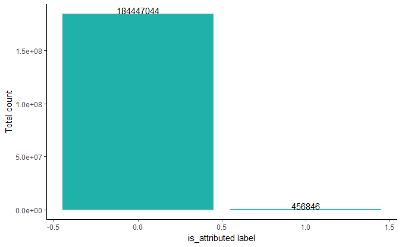

```r
df %>% select(is_attributed) %>% group_by(is_attributed) %>% summarize(count = n()) %>% ggplot(aes(is_attributed,count)) + geom_bar(stat = "identity", fill = "lightseagreen") + theme_classic() + xlab("is_attributed label") + ylab('Total count') + geom_text(aes(label = count, vjust = "bottom"))
```

## 4.2 Time period

We can see that the train data span across 4 days, as mentioned in kaggle’s introduction of this competition:

```
To support your modeling, they have provided a generous dataset covering approximately 200 million clicks over 4 days!
```

Data collected takes place between 06/11-09/11

```r
df$click_time <- ymd_hms(df$click_time)
unique(date(df$click_time))
```

We can also see that the data span across every sec. So from the start of 2017-11-06 14:32:21 till the end of 2017-11-09 16:00:00

```r
#https://stackoverflow.com/questions/32364018/plotting-posixct-timestamp-series-with-ggplot2
f1 <- ymd_hms('2017-11-07 00:00:00')
df %>% filter(click_time <= f1) %>% tail(1000)
```

|  | ip | app | device | os | channel | click_time | is_attributed |
| --- | --- | --- | --- | --- | --- | --- | --- |
| 9308383 | 174352 | 15 | 1 | 19 | 140 | 2017-11-06 23:59:59 | 0 |
| 9308384 | 95766 | 3 | 1 | 22 | 424 | 2017-11-06 23:59:59 | 0 |
| 9308385 | 74493 | 27 | 1 | 19 | 153 | 2017-11-06 23:59:59 | 0 |
| 9308386 | 96844 | 26 | 1 | 37 | 121 | 2017-11-06 23:59:59 | 0 |
| 9308387 | 22866 | 20 | 1 | 19 | 478 | 2017-11-06 23:59:59 | 0 |
| 9308388 | 116542 | 5 | 1 | 13 | 377 | 2017-11-06 23:59:59 | 0 |
| 9308389 | 8505 | 12 | 1 | 18 | 245 | 2017-11-06 23:59:59 | 0 |
| 9308390 | 25614 | 2 | 1 | 28 | 205 | 2017-11-06 23:59:59 | 0 |
| 9308391 | 71912 | 18 | 1 | 16 | 107 | 2017-11-06 23:59:59 | 0 |
| 9308392 | 50136 | 15 | 1 | 22 | 245 | 2017-11-06 23:59:59 | 0 |

[output cut: 990 more lines]

## 4.3 Click time

### 4.3.1 Day

Interestingly, 06/11 is a Monday. Does this mean that there is some form of Monday blues? Most of the 0s probably came from 06/11.

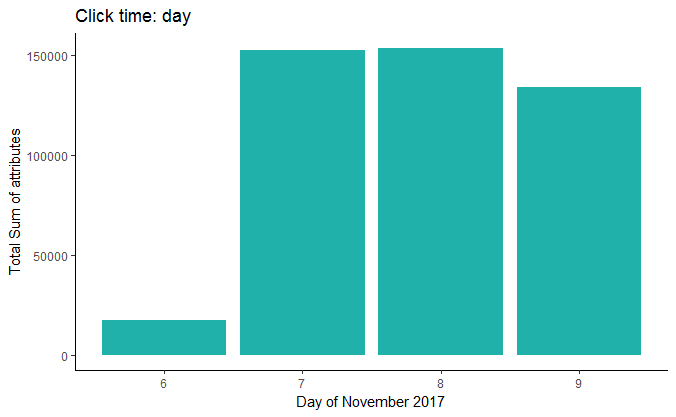

### 4.3.2 Hourly

Note that this data set is based in China, and time in China is **8 hours ahead**. Highest click time hovers around UTC 1-4 am.

| UTC | China |
| --- | --- |
| 1 | 9am |
| 2 | 10 am |
| 3 | 11 am |
| 4 | 12 am |

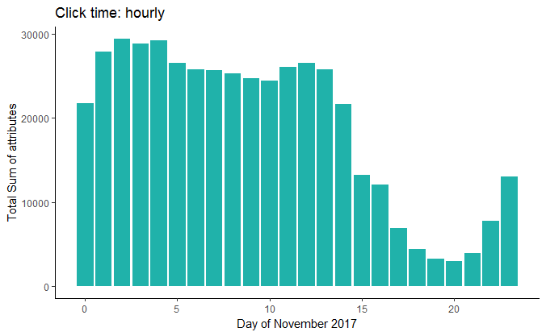

## 4.4 Parallel Set

Inspired from: [Kailex](https://www.kaggle.com/kailex/talkingdata-eda-and-class-imbalance/notebook), [Times](http://datavizproject.com/data-type/alluvial-diagram/), [Aaron, stackoverflow](https://stats.stackexchange.com/questions/12029/is-it-possible-to-create-parallel-sets-plot-using-r), [Dataviz](http://datavizproject.com/data-type/parallel-sets/)

```r
graph_df <- df %>% filter(is_attributed == 1) %>% group_by(app,device,os,channel) %>% summarise(total = n()) %>% ungroup()
graph_df$app <- as.factor(graph_df$app)
graph_df$device <- as.factor(graph_df$device)
graph_df$os <- as.factor(graph_df$os)
graph_df$channel <- as.factor(graph_df$channel)
```

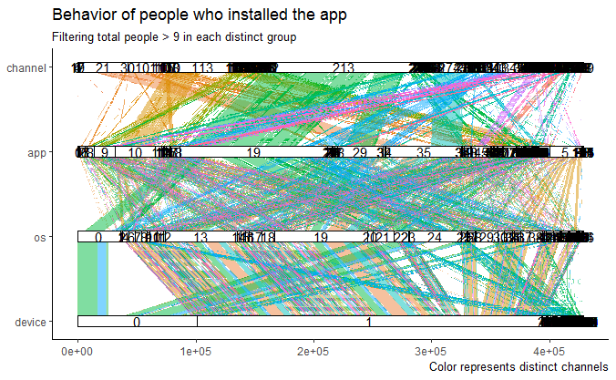

Filtering for the smaller groups, we can see:

- there are less device 0 users. Majority are using device 1,2…etc
- Again, people who installed app 19 comes from channel 213

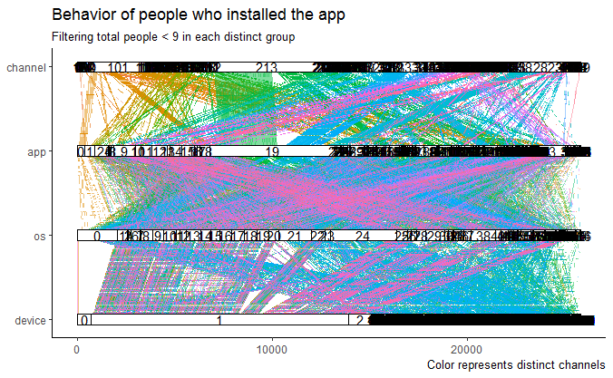

```r
#https://cran.r-project.org/web/packages/ggalluvial/vignettes/ggalluvial.html
as.data.frame(graph_df %>% filter(total < 9)) %>% ggplot(aes(weight = total, axis1 = device, axis2 = os, axis3 = app, axis4 = channel)) +
  geom_alluvium(aes(fill = channel), width = 0, knot.pos = 0, reverse = FALSE) +
  # no legneds
  guides(fill = FALSE) +
  geom_stratum(width = 1/8, reverse = FALSE) +
  geom_text(stat = "stratum", label.strata = TRUE, reverse = FALSE) +
  theme_classic() +
  scale_x_continuous(breaks = 1:4, labels = c("device", "os", "app", "channel")) +
  coord_flip() + labs(title = "Behavior of people who installed the app",
                      subtitle = "Filtering total people < 9 in each distinct group",
                      caption = "Color represents distinct channels"
                      )
```